# treestructure applied to structured coalescent simulation

Erik Volz

2026-07-05

# Structured coalescent simulation

This example shows the function `trestruct` applied to a simulated structured coalescent tree that includes samples from a large constant size population and samples from three small “outbreaks” which are growing exponentially. These simulations were generated with the [phydynR package](https://emvolz-phylodynamics.github.io/phydynR/).

```r
library(ape)
library(treestructure)
library(ggtree)
```

Load the tree:

```r
( tree <- ape::read.tree( system.file('sim.nwk', package = 'treestructure') ) )
```

```
#>
#> Phylogenetic tree with 275 tips and 274 internal nodes.
#>
#> Tip labels:
#>   1, 1, 1, 1, 1, 1, ...
#>
#> Rooted; includes branch length(s).
```

Note that the tip labels corresponds to the deme of each sample. ‘1’ is the constant size reservoir, and ‘0’ is the exponentially growing deme.

This will run the `treestructure` algorithm under default settings:

```r
s <- trestruct( tree )
```

```
#> Tree has NA or duplicated tip labels. Adding a unique id.
#> Finding splits under nodes: 276
#> Finding splits under nodes: 276 526
#> Finding splits under nodes: 276 421 526 530
#> Finding splits under nodes: 276 421 422 473
```

The `treestructure` algorithm searches from root to tips of the phylogenetic tree. The message printed on screen, `Finding splits under nodes`, reports which nodes the algorithm is currently testing.

By default `trestruct` calibrates the split threshold to a target false discovery rate (`fdr = 0.2`), so that the expected proportion of spuriously designated clusters is controlled across the whole tree. The printed output reports this target and a global test for whether the tree has any structure at all:

```r
print(s)
```

```
#> Call:
#> trestruct(tre = tree)
#>
#> Target FDR: 0.2 (bonferroni correction)
#> Global structure test: max|z| = 5.60 over 52 candidates, p = 1.1e-06
#> Number of clusters: 6
#> Number of partitions: 3
#> Number of taxa in each cluster:
#>
#>   1   2   3   4   5   6
#>  12  13 200  10  15  25
#> Number of taxa in each partition:
#>
#>   1   2   3
#>  12  53 210
#> ...
#> For complete data, use `as.data.frame(...)`
```

## Plotting results

The default plotting behavior uses the `ggtree` package if available.

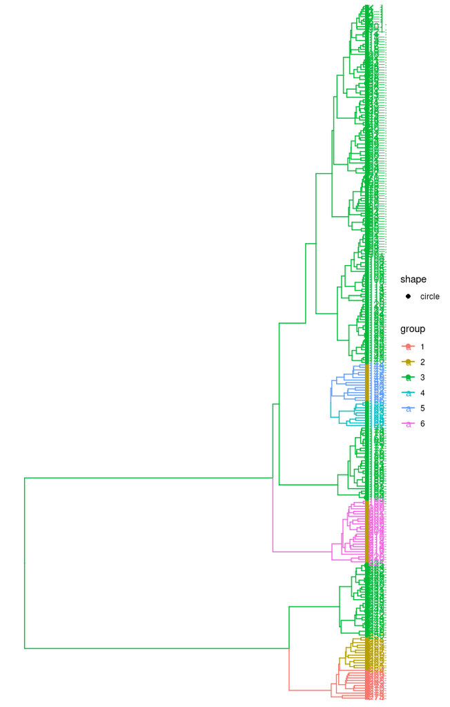

```r
plot(s)  + ggtree::geom_tiplab()
```

If not, or if desired, `ape` plots are available

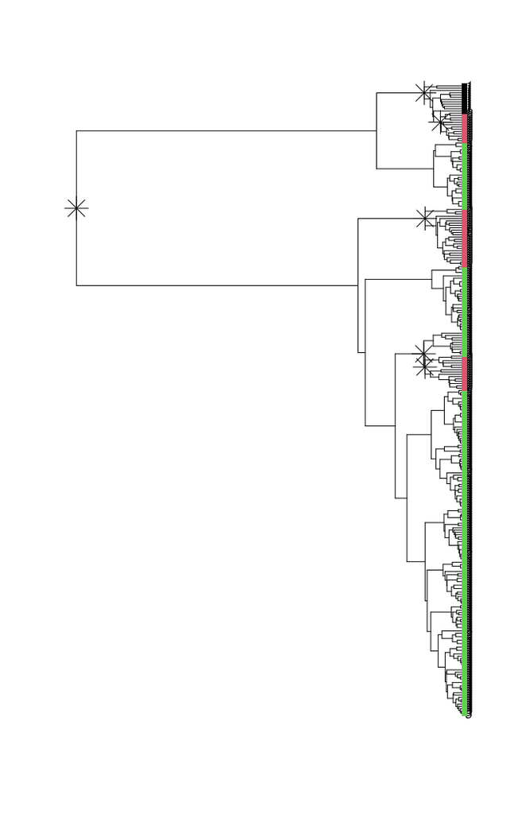

```r
plot( s, use_ggtree = FALSE )
```

For subsequent analysis, you may want to turn the `treestructure` result into a dataframe:

```r
structureData <- as.data.frame( s )
head( structureData )
```

```
#>   taxon cluster partition
#> 1   1_1       3         3
#> 2   2_1       3         3
#> 3   3_1       3         3
#> 4   4_1       3         3
#> 5   5_1       3         3
#> 6   6_1       3         3
```

Each cluster and partition assignment is stored as a factor. You could use `split` to get a data frame for each partition. Suppose we want a tree corresponding to partition 1:

```r
with ( structureData,
       ape::keep.tip(s$tree, taxon[ partition==1 ] )
       ) -> partition1
partition1
```

```
#>
#> Phylogenetic tree with 12 tips and 11 internal nodes.
#>
#> Tip labels:
#>   264_0, 265_0, 266_0, 267_0, 268_0, 269_0, ...
#>
#> Rooted; includes branch length(s).
```

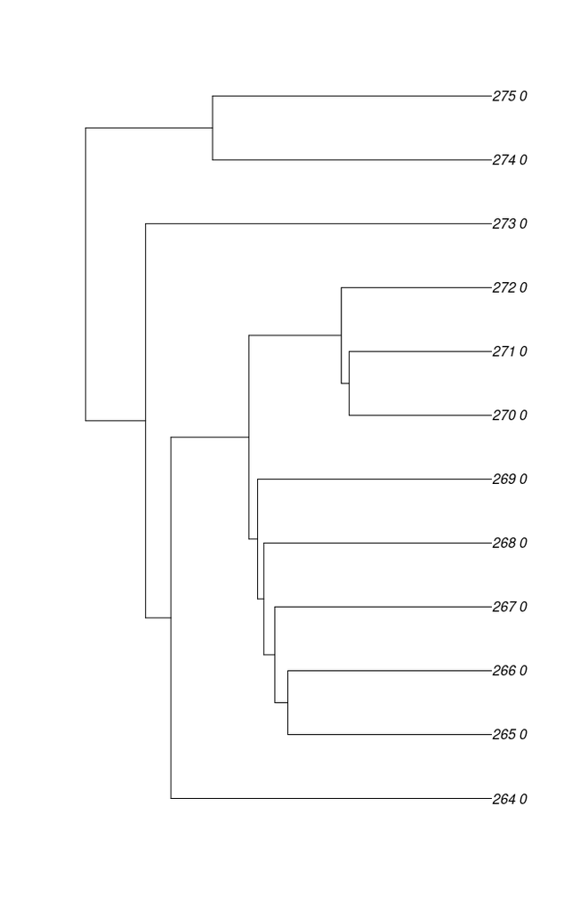

```r
plot(partition1)
```

# Parameter choice and number of clusters

```r
trestruct( tree, minCladeSize = 5 )
```

```
#> Tree has NA or duplicated tip labels. Adding a unique id.
#> Finding splits under nodes: 276
#> Finding splits under nodes: 276 526
#> Finding splits under nodes: 276 421
#> Finding splits under nodes: 276 473
#> Call:
#> trestruct(tre = tree, minCladeSize = 5)
#>
#> Target FDR: 0.2 (bonferroni correction)
#> Global structure test: max|z| = 5.60 over 109 candidates, p = 2.3e-06
#> Number of clusters: 4
#> Number of partitions: 2
#> Number of taxa in each cluster:
#>
#>   1   2   3   4
#>  25  25 200  25
#> Number of taxa in each partition:
#>
#>   1   2
#>  75 200
#> ...
#> For complete data, use `as.data.frame(...)`
```

2. The split threshold — how readily a clade is designated a new cluster. By default this is set by a false discovery rate (`fdr`); alternatively it can be set by a subjective significance `level`, or that `level` chosen automatically with the CH index.

### False discovery rate (default)

By default the threshold is calibrated to a target false discovery rate, so that `fdr` has an interpretable, whole-tree error-rate meaning:

```r
trestruct( tree, fdr = 0.05 )
```

```
#> Tree has NA or duplicated tip labels. Adding a unique id.
#> Finding splits under nodes: 276
#> Finding splits under nodes: 276 526
#> Finding splits under nodes: 276 421
#> Finding splits under nodes: 276 473
#> Call:
#> trestruct(tre = tree, fdr = 0.05)
#>
#> Target FDR: 0.05 (bonferroni correction)
#> Global structure test: max|z| = 5.60 over 52 candidates, p = 1.1e-06
#> Number of clusters: 4
#> Number of partitions: 2
#> Number of taxa in each cluster:
#>
#>   1   2   3   4
#>  25  25 200  25
#> Number of taxa in each partition:
#>
#>   1   2
#>  75 200
#> ...
#> For complete data, use `as.data.frame(...)`
```

The false discovery rate vignette explains what the rate controls, the global test for any structure, and the effect of serial (heterochronous) sampling.

### Subjective significance level

Supplying a `level` (without `fdr`) uses it instead as a fixed per-test significance. This is a subjective clustering threshold rather than an error rate: raising it detects more clusters but also increases the false positive rate.

```r
trestruct( tree, level = 0.05 )
```

```
#> Tree has NA or duplicated tip labels. Adding a unique id.
#> Finding splits under nodes: 276
#> Finding splits under nodes: 276 526
#> Finding splits under nodes: 276 421
#> Finding splits under nodes: 276 473
#> Call:
#> trestruct(tre = tree, level = 0.05)
#>
#> Significance level: 0.05
#> Global structure test: max|z| = 5.60 over 52 candidates, p = 1.1e-06
#> Number of clusters: 4
#> Number of partitions: 2
#> Number of taxa in each cluster:
#>
#>   1   2   3   4
#>  25  25 200  25
#> Number of taxa in each partition:
#>
#>   1   2
#>  75 200
#> ...
#> For complete data, use `as.data.frame(...)`
```

The best value of `level` depends on your application. One way to choose it is to use additional data associated with each sample, selecting the `level` that gives clusters explaining the most variance in a variable of interest (e.g. using the cluster as a factor in an ANOVA).

### CH index

Alternatively, in the absence of any additional data, the `treestructure` package supports using the [CH index](https://en.wikipedia.org/wiki/Calinski%E2%80%93Harabasz_index) to compare different `level`s. This statistic is based on the ratio of the between-cluster and within-cluster variance of the time of each node (distance from the root) and returns the `level` such that this ratio is maximized. If you wish to use the CH index, pass `level = NULL` to `trestruct`, and read documentation for the `levellb`, `levelub`, and `res` parameters.